# (Ford GoBike System feb 2019 Explantory show) by (Mohamad Ahmad Hassan)

## Investigation Overview

# This presention will be used to try to find some insights which follow: To find the count of people using the share bike system To find the Gender distrbution of users How Much time diffrent users types spend using the bikes Suggest that geneder equality could promote our service by showing that gender usage or duration of usage to the service

## Dataset Overview

# This Dataset contain the following: Duration of trips in seconds and we changed that to minutes and hours for better understaning Members birth years and we changed that to Age User Type either Consumer or Subscriber Members genders

## (Gender distribution )

## This visual shows us the distrbuation of genders using ford Gobike share system

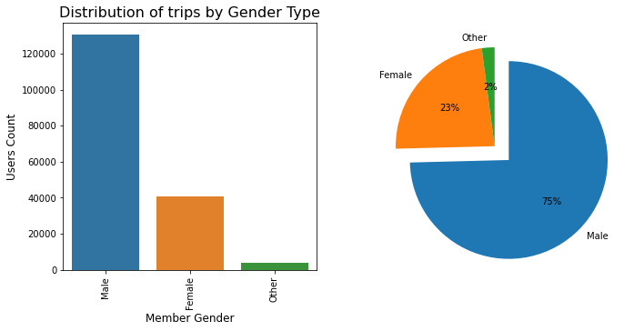

## (Age Of Riders )

## This visual shows us the distrbuation of Ages using ford Gobike share system

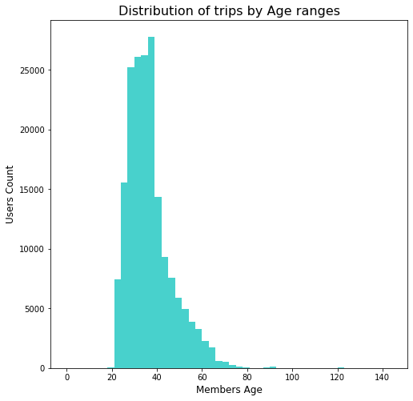

## (The Distrbution of customers and subscribers trips duration)

## This visual shows us the distrbuation of User Types and duration spent using ford Gobike share system

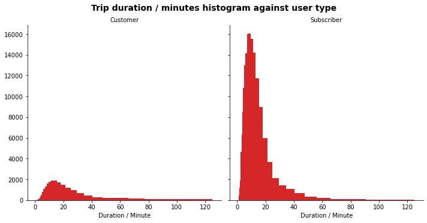

## (Distribution of trips Duration by Gender Type)

## This visual shows us the distrbuation of Gender Type and duration spent using ford Gobike share system In this plot we can see that both other gender and Females is having longer duration of trips than Males who are supposed to be physically more capable , we can use that point to promote our service to more female users

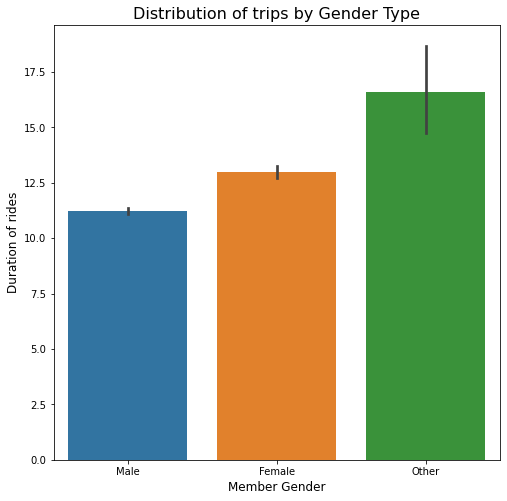